# Assignment 3: Sentiment Classification Reflection

## Neural Models for Sentiment Classification

**Author:** Junho Hong

This notebook contains analysis and reflection on six neural models trained for sentiment classification on the Financial PhraseBank dataset: - MLP (mean-pooled FastText) - RNN (SentenceTransformer sequences) - LSTM (padded FastText sequences) - GRU (SentenceTransformer sequences) - BERT (pretrained transformer, fine-tuned) - GPT-2 (pretrained transformer, fine-tuned)

## Summary of Results

| Rank | Model | Test Accuracy | Test Macro F1 | Architecture Type |
| --- | --- | --- | --- | --- |
| 1 | **BERT** | **0.8253** | **0.8090** | Pretrained Transformer (Encoder) |
| 2 | **GPT-2** | 0.8061 | 0.7931 | Pretrained Transformer (Decoder) |
| 3 | **GRU** | 0.7785 | 0.7520 | Sequential (SentenceTransformer) |
| 4 | **LSTM** | 0.7648 | 0.7375 | Sequential (FastText) |
| 5 | **RNN** | 0.7180 | 0.7023 | Sequential (SentenceTransformer) |
| 6 | **MLP** | 0.7001 | 0.6699 | Feed-forward (mean pooling) |

## 1. Training Dynamics

### 1.1 MLP Training Curves

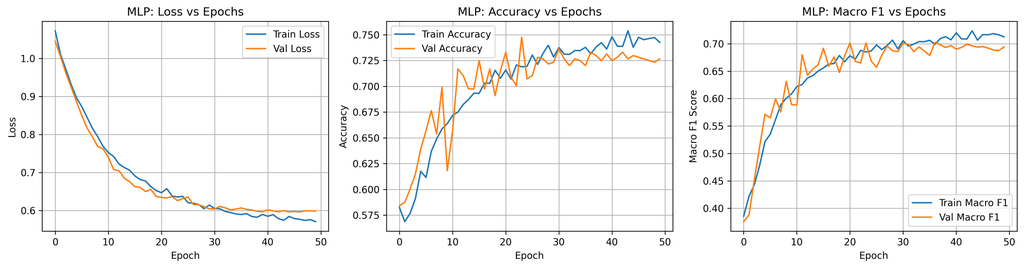

MLP Training Curves

### 1.2 LSTM Training Curves

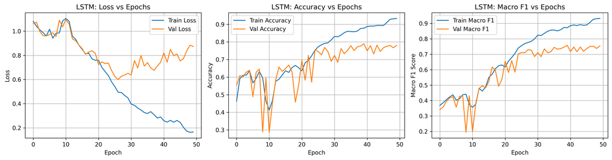

LSTM Training Curves

### 1.3 Analysis: Overfitting vs Underfitting

#### MLP Model:

The MLP shows **slight overfitting** characteristics: - Training accuracy reaches ~75% while validation plateaus at ~72-73% - Training F1 reaches ~0.71 while validation plateaus at ~0.70 - Training loss continues decreasing to ~0.58 while validation loss stabilizes at ~0.60 - The gap between train/val metrics is relatively small (~2-3%), indicating mild overfitting

**Evidence:** The training curves show steady improvement on the training set while validation metrics plateau after epoch 20, creating a small but consistent gap.

#### LSTM Model:

The LSTM shows **significant overfitting**: - Training accuracy reaches ~93% while validation plateaus at ~77% - Training F1 reaches ~0.92 while validation plateaus at ~0.75 - Training loss drops to ~0.17 while validation loss increases to ~0.88 - Large gap (~16% accuracy, ~0.17 F1) between train and validation performance

#### Why LSTM overfits more than MLP:

1. **Model Capacity**: LSTM has more parameters (~280K) than MLP (~39K)
2. **Sequential Information**: LSTM can memorize specific word sequences from training data
3. **Complexity**: Two-layer LSTM with recurrent connections has higher capacity to fit training data patterns

### 1.4 Architectural/Training Changes to Address Overfitting

#### For LSTM:

1. **Stronger Regularization**:
   - Increase dropout from 0.3 to 0.5
   - Add recurrent dropout in LSTM layers
   - Apply weight decay (L2 regularization)
2. **Reduce Model Capacity**:
   - Use 1 LSTM layer instead of 2
   - Reduce hidden dimension from 128 to 64
3. **Gradient Clipping**: Prevent exploding gradients that can cause overfitting
4. **Learning Rate Scheduling**: More aggressive learning rate reduction when validation performance plateaus

### 1.5 Effect of Class Weights on Training

Class weights were computed based on the imbalanced distribution: - Negative: 604 samples (weight ≈ 2.67) - Neutral: 2879 samples (weight ≈ 0.56) - Positive: 1363 samples (weight ≈ 1.18)

#### Impact on Training Stability:

1. **Loss Weighting**: Negative class errors contribute ~5x more to loss than Neutral class errors
2. **Learning Focus**: Model learns to pay more attention to minority classes (Negative, Positive)
3. **Macro F1 Improvement**: Without class weights, model would overpredict Neutral class; with weights, performance is more balanced across classes

#### Impact on Final Performance:

- Class weights helped achieve better **Macro F1** scores (which treat all classes equally)
- Without weights, the model would likely achieve higher overall accuracy but lower F1 on minority classes
- The weighted loss made training more stable by preventing the model from simply learning to predict the majority class

## 2. Model Performance and Error Analysis

### 2.1 MLP Confusion Matrix

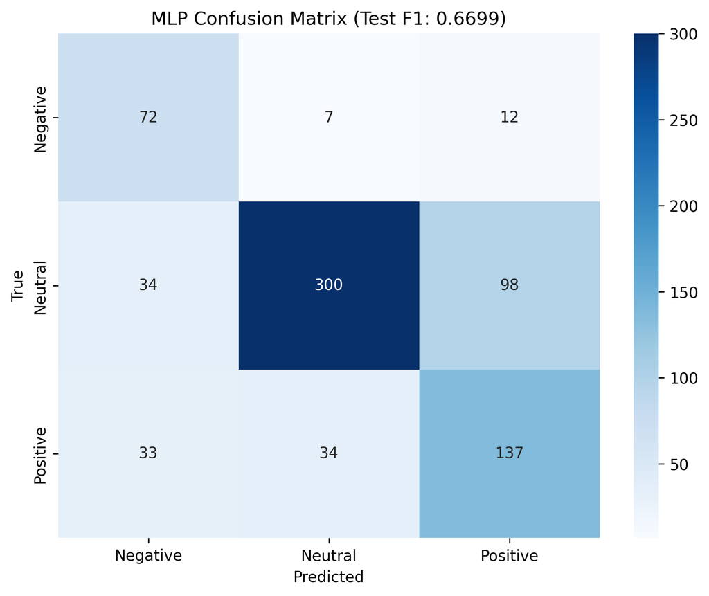

MLP Confusion Matrix

**Test Performance:** - Accuracy: 70.01% - Macro F1: 0.6699

### 2.2 LSTM Confusion Matrix

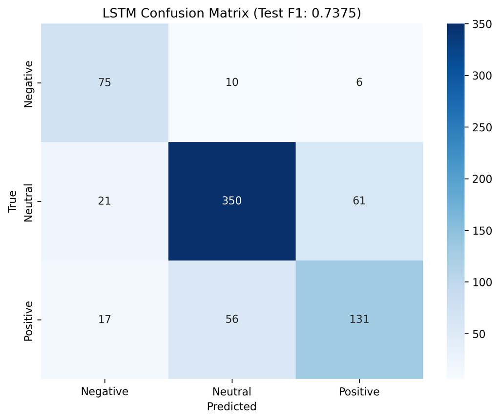

LSTM Confusion Matrix

**Test Performance:** - Accuracy: 76.48% - Macro F1: 0.7375

### 2.3 Generalization Comparison

**LSTM generalizes better to the test set** based on multiple metrics:

| Metric | MLP | LSTM | Difference |
| --- | --- | --- | --- |
| Test Accuracy | 70.01% | 76.48% | **+6.47%** |
| Test Macro F1 | 0.6699 | 0.7375 | **+0.0676** |

#### Evidence from Confusion Matrices:

**MLP Errors:** - Negative class: 72/91 correct (79.1% recall) - Neutral class: 300/432 correct (69.4% recall) - Positive class: 137/204 correct (67.2% recall) - High confusion between Neutral→Positive (98 errors)

**LSTM Errors:** - Negative class: 75/91 correct (82.4% recall) - Neutral class: 350/432 correct (81.0% recall) - Positive class: 131/204 correct (64.2% recall) - Better at distinguishing Neutral class (81% vs 69%)

#### Why LSTM Generalizes Better:

1. **Sequential Context**: LSTM captures word order and dependencies that MLP’s mean pooling loses
2. **Contextual Understanding**: LSTM processes sequences token-by-token, preserving syntactic structure

### 2.4 Most Frequently Misclassified Class

#### Analysis from Confusion Matrices:

**MLP:** - Negative: 19 errors out of 91 (20.9% error rate) - Neutral: 132 errors out of 432 (30.6% error rate) - Positive: **67 errors out of 204 (32.8% error rate)** ← **Highest**

**LSTM:** - Negative: 16 errors out of 91 (17.6% error rate) - Neutral: 82 errors out of 432 (19.0% error rate) - Positive: **73 errors out of 204 (35.8% error rate)** ← **Highest**

**Answer: The Positive class is most frequently misclassified in both models.**

#### Reasons for Positive Class Misclassification:

1. **Semantic Ambiguity in Financial Text**:
   - Financial positive sentiment is often understated (e.g., “modest gains,” “slight improvement”)
   - These phrases lack strong positive indicators, making them hard to distinguish from Neutral
   - Example: “The company reported stable earnings” could be Neutral or mildly Positive
2. **Model Limitations**:
   - Both models struggle to capture nuanced sentiment in professional financial writing
   - Mean pooling (MLP) loses word order that might indicate positive framing
   - LSTM’s sequential processing doesn’t fully capture subtle financial sentiment cues

## 3. Cross-Model Comparison

### 3.1 Additional Model Confusion Matrices

#### RNN

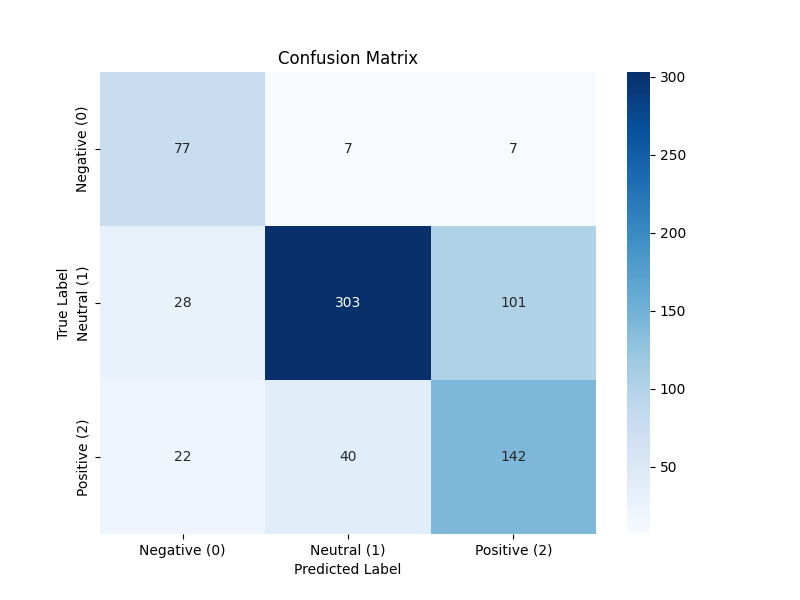

**Performance:** Accuracy = 71.80%, Macro F1 = 0.7023

#### GRU

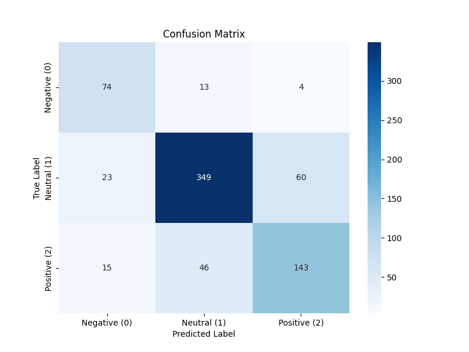

**Performance:** Accuracy = 77.85%, Macro F1 = 0.7520

#### BERT

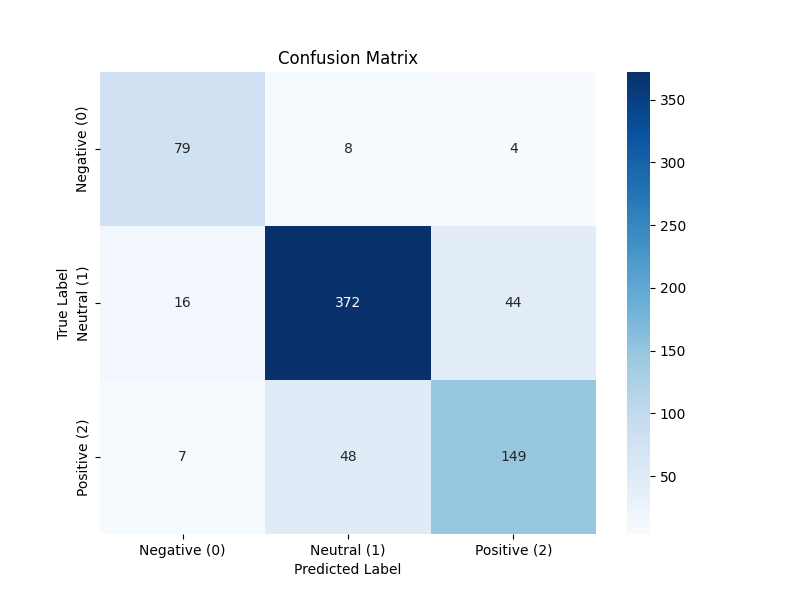

**Performance:** Accuracy = 82.53%, Macro F1 = 0.8090

#### GPT-2

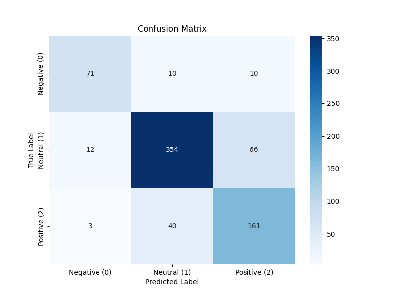

**Performance:** Accuracy = 80.61%, Macro F1 = 0.7931

### 3.2 Training Curves Comparison

#### RNN Training Curves

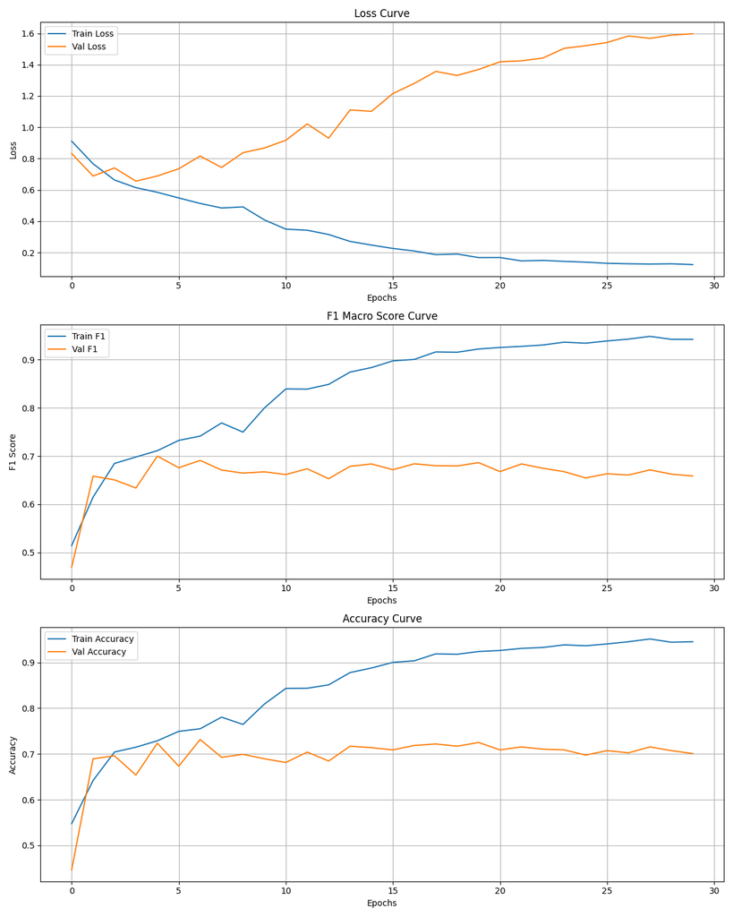

RNN Learning Curves

#### GRU Training Curves

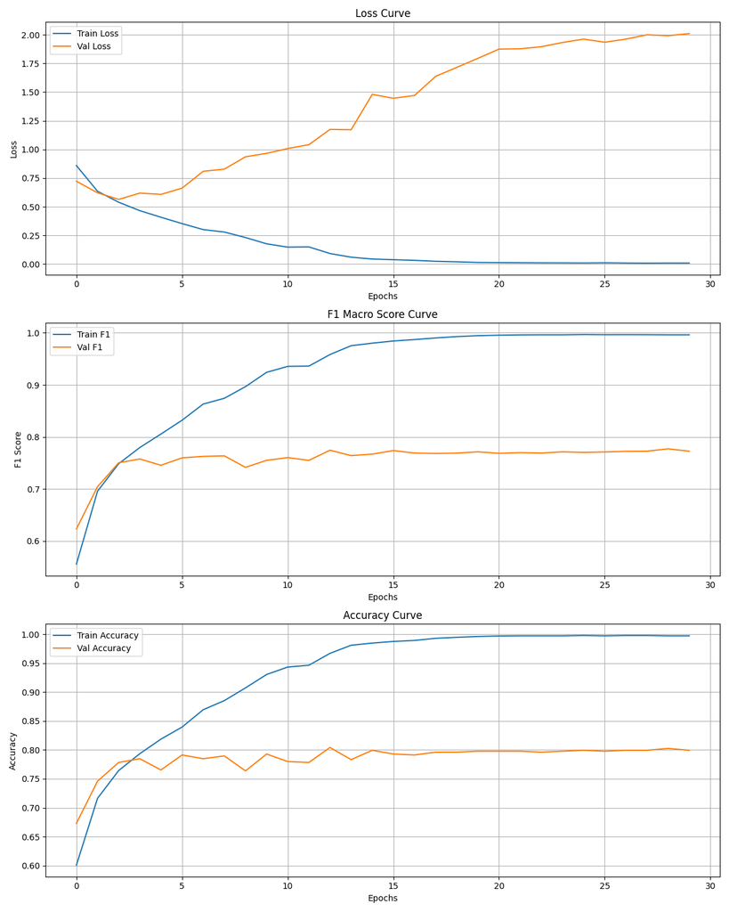

GRU Learning Curves

#### BERT Training Curves

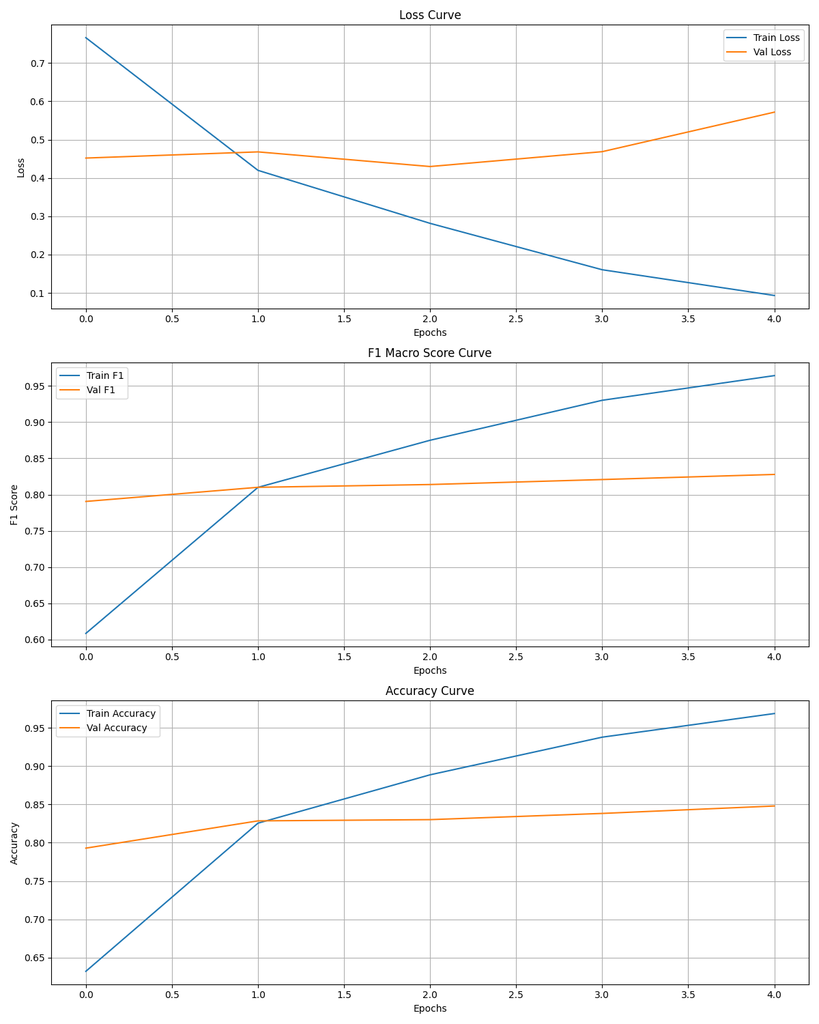

BERT Learning Curves

#### GPT-2 Training Curves

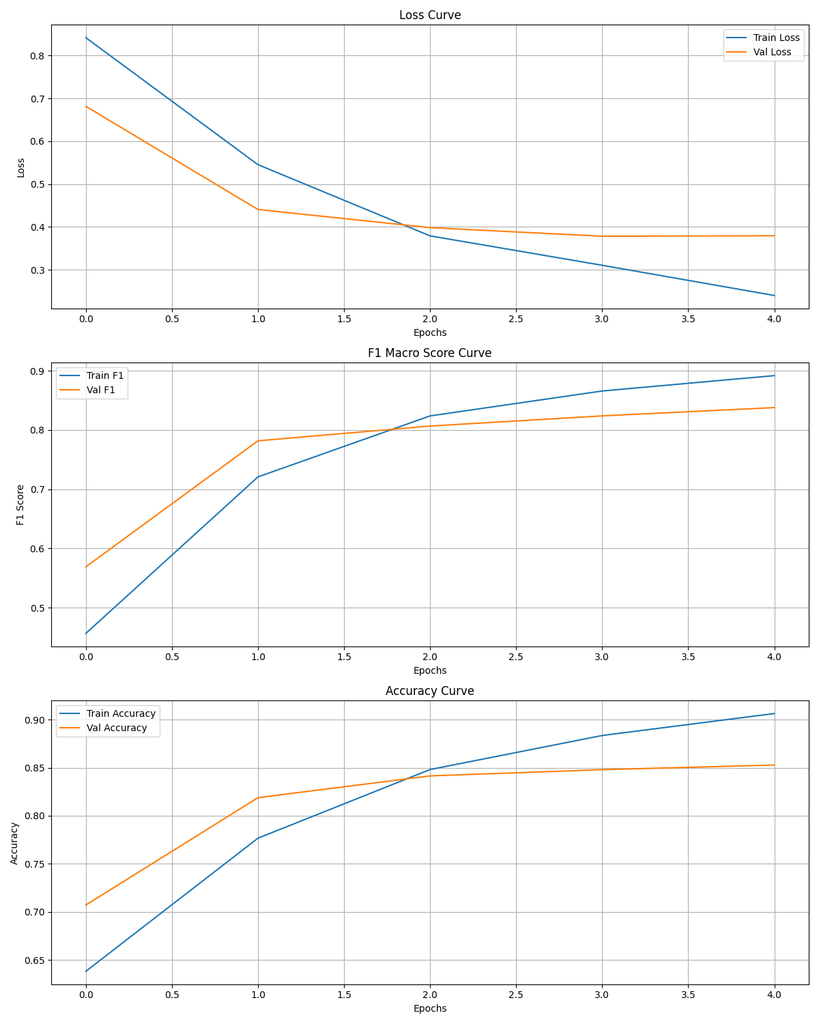

GPT Learning Curves

### 3.3 How Mean-Pooled FastText Embeddings Limited MLP Performance

Mean pooling creates a **bag-of-words representation** that loses information:

#### What is Lost:

1. **Word Order**: “profits increased significantly” vs “significantly increased profits” → same vector
2. **Negation**: “not good” vs “good” → vectors are averaged, weakening negation signal
3. **Syntactic Structure**: Cannot capture subject-verb-object relationships
4. **Context-Dependent Meaning**: “the bank reported losses” (financial) vs “the river bank” → word “bank” has same embedding

#### Impact on Sentiment Classification:

- **Example 1**: “The company did not meet expectations” vs “The company met expectations”
  - Mean pooling produces very similar vectors despite opposite sentiments
  - MLP cannot distinguish these because negation word “not” is averaged in
- **Example 2**: “Sales increased while profits decreased”
  - Sequential models see the contrast structure
  - MLP only sees average of “increased” and “decreased” embeddings

#### Quantitative Evidence:

- MLP F1: 0.6699 (lowest among all models)
- Gap to LSTM: +0.0676 F1 (10% relative improvement)
- Gap to BERT: +0.1391 F1 (21% relative improvement)

### 3.4 LSTM’s Sequential Processing Advantage Over MLP

**1. Preserves Word Order:** - LSTM processes tokens sequentially: word₁ → word₂ → word₃ - Can learn that “not profitable” is different from “profitable not”

**2. Captures Long-Range Dependencies:** - LSTM’s memory cells maintain information across the sequence - Can connect subject at start of sentence to verb at end

**3. Handles Negation Better:** - Sequential processing allows LSTM to learn negation patterns - “not good” is processed as: “not” updates hidden state → “good” is modulated by that state

**4. Contextual Word Representation:** - Same word in different positions/contexts produces different hidden states - “bank” in “financial bank” vs “river bank” gets different representations based on preceding words

### 3.5 Did Fine-Tuned LLMs Outperform Classical Baselines? Ranking and Key Factors

**Answer: Yes, significantly.** BERT (F1 0.8090) and GPT-2 (0.7931) outperform the best classical baseline, GRU (0.7520), by about 5–8% relative.

#### Ranking by Test Macro F1

[output not shown]

#### Why LLMs Lead

1. **Pretraining & transfer** — BERT/GPT are pretrained on huge corpora; fine-tuning adapts that knowledge to financial sentiment. Classical models learn from scratch on ~4.8k samples.
2. **Contextual embeddings** — BERT/GPT give context-dependent representations; classical models use static embeddings (e.g. FastText/SentenceTransformer).
3. **Self-attention** — Transformers let every token attend to every other token; RNNs are sequential and can dilute long-range information.
4. **Bidirectionality (BERT)** — BERT sees full context (left and right); RNNs and GPT are unidirectional.

## AI Use Disclosure

In completing this assignment, I used Claude for: - Debugging PyTorch compatibility issues when writing scripts - Structuring code with proper documentation and comments - Organizing the structure of this reflection notebook